# Risk Factor Analysis

## Outcome Variable

**Outcome Variable:** whz

## Predictor Variables

**Intervention Variable:** nchldlt5

**Adjustment Set:**

- arm
- W_mage
- meducyrs
- feducyrs
- hhwealth_quart
- hfoodsec
- W_mhtcm
- W_mwtkg
- W_mbmi
- W_nrooms
- W_parity
- impfloor
- impsan
- safeh20
- delta_W_mage
- delta_meducyrs
- delta_feducyrs
- delta_hhwealth_quart
- delta_hfoodsec
- delta_W_mhtcm
- delta_W_mwtkg
- delta_W_mbmi
- delta_W_nrooms
- delta_W_parity
- delta_impfloor
- delta_impsan
- delta_safeh20

## Stratifying Variables

The analysis was stratified on these variable(s):

- agecat
- studyid
- country

## Data Summary

| agecat | studyid | country | nchldlt5 | n_cell | n |
| --- | --- | --- | --- | --- | --- |
| Birth | IRC | INDIA | 1 | 72 | 343 |
| Birth | IRC | INDIA | 2+ | 271 | 343 |
| Birth | JiVitA-3 | BANGLADESH | 1 | 10878 | 17991 |
| Birth | JiVitA-3 | BANGLADESH | 2+ | 7113 | 17991 |
| Birth | NIH-Crypto | BANGLADESH | 1 | 504 | 707 |
| Birth | NIH-Crypto | BANGLADESH | 2+ | 203 | 707 |
| Birth | PROVIDE | BANGLADESH | 1 | 385 | 532 |
| Birth | PROVIDE | BANGLADESH | 2+ | 147 | 532 |
| 6 months | IRC | INDIA | 1 | 88 | 408 |
| 6 months | IRC | INDIA | 2+ | 320 | 408 |
| 6 months | JiVitA-3 | BANGLADESH | 1 | 10872 | 16773 |
| 6 months | JiVitA-3 | BANGLADESH | 2+ | 5901 | 16773 |
| 6 months | LCNI-5 | MALAWI | 1 | 390 | 811 |
| 6 months | LCNI-5 | MALAWI | 2+ | 421 | 811 |
| 6 months | NIH-Crypto | BANGLADESH | 1 | 507 | 715 |
| 6 months | NIH-Crypto | BANGLADESH | 2+ | 208 | 715 |
| 6 months | PROVIDE | BANGLADESH | 1 | 438 | 603 |
| 6 months | PROVIDE | BANGLADESH | 2+ | 165 | 603 |
| 6 months | TanzaniaChild2 | TANZANIA, UNITED REPUBLIC OF | 1 | 1390 | 2019 |
| 6 months | TanzaniaChild2 | TANZANIA, UNITED REPUBLIC OF | 2+ | 629 | 2019 |
| 24 months | IRC | INDIA | 1 | 89 | 409 |
| 24 months | IRC | INDIA | 2+ | 320 | 409 |
| 24 months | JiVitA-3 | BANGLADESH | 1 | 5434 | 8593 |
| 24 months | JiVitA-3 | BANGLADESH | 2+ | 3159 | 8593 |
| 24 months | LCNI-5 | MALAWI | 1 | 277 | 555 |
| 24 months | LCNI-5 | MALAWI | 2+ | 278 | 555 |
| 24 months | NIH-Crypto | BANGLADESH | 1 | 357 | 514 |
| 24 months | NIH-Crypto | BANGLADESH | 2+ | 157 | 514 |
| 24 months | PROVIDE | BANGLADESH | 1 | 424 | 579 |
| 24 months | PROVIDE | BANGLADESH | 2+ | 155 | 579 |
| 24 months | TanzaniaChild2 | TANZANIA, UNITED REPUBLIC OF | 1 | 5 | 6 |
| 24 months | TanzaniaChild2 | TANZANIA, UNITED REPUBLIC OF | 2+ | 1 | 6 |

The following strata were considered:

- agecat: 24 months, studyid: IRC, country: INDIA
- agecat: 24 months, studyid: JiVitA-3, country: BANGLADESH
- agecat: 24 months, studyid: LCNI-5, country: MALAWI
- agecat: 24 months, studyid: NIH-Crypto, country: BANGLADESH
- agecat: 24 months, studyid: PROVIDE, country: BANGLADESH
- agecat: 24 months, studyid: TanzaniaChild2, country: TANZANIA, UNITED REPUBLIC OF
- agecat: 6 months, studyid: IRC, country: INDIA
- agecat: 6 months, studyid: JiVitA-3, country: BANGLADESH
- agecat: 6 months, studyid: LCNI-5, country: MALAWI
- agecat: 6 months, studyid: NIH-Crypto, country: BANGLADESH
- agecat: 6 months, studyid: PROVIDE, country: BANGLADESH
- agecat: 6 months, studyid: TanzaniaChild2, country: TANZANIA, UNITED REPUBLIC OF
- agecat: Birth, studyid: IRC, country: INDIA
- agecat: Birth, studyid: JiVitA-3, country: BANGLADESH
- agecat: Birth, studyid: NIH-Crypto, country: BANGLADESH
- agecat: Birth, studyid: PROVIDE, country: BANGLADESH

### Dropped Strata

Some strata were dropped due to rare outcomes:

- agecat: 24 months, studyid: TanzaniaChild2, country: TANZANIA, UNITED REPUBLIC OF

## Methods Detail

We’re interested in the causal parameters $E[Y_a]$ for all values of $a \in \mathcal{A}$. These parameters represent the mean outcome if, possibly contrary to fact, we intervened to set all units to have $A=a$. Under the randomization and positivity assumptions, these are identified by the statistical parameters $\psi_a=E_W[E_{Y|A,W}(Y|A=a,W)]$. In addition, we’re interested in the mean of $Y$, $E[Y]$ under no intervention (the observed mean). We will estimate these parameters by using SuperLearner to fit the relevant likelihood factors – $E_{Y|A,W}(Y|A=a,W)$ and $p(A=a|W)$, and then updating our likelihood fit using a joint TMLE.

For unadjusted analyses ($W=\{\}$), initial likelihoods were estimated using Lrnr_glm to estimate the simple $E(Y|A)$ and Lrnr_mean to estimate $p(A)$. For adjusted analyses, a small library containing Lrnr_glmnet, Lrnr_xgboost, and Lrnr_mean was used.

Having estimated these parameters, we will then use the delta method to estimate relative risks and attributable risks relative to a prespecified baseline level of $A$.

# Results Detail

## Results Plots

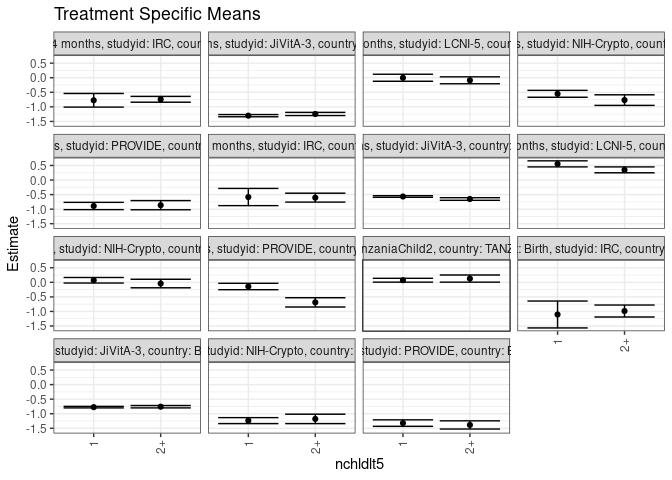

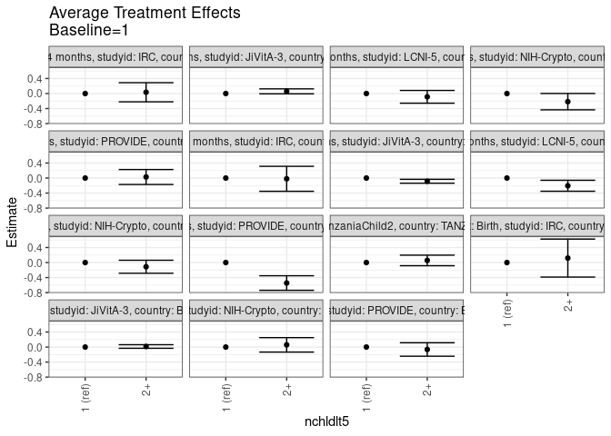

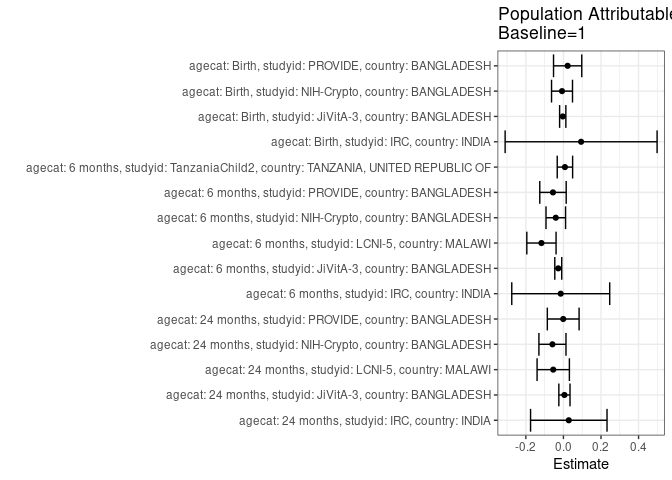

## Results Table

### Parameter: TSM

| agecat | studyid | country | intervention_level | baseline_level | estimate | ci_lower | ci_upper |
| --- | --- | --- | --- | --- | --- | --- | --- |
| Birth | IRC | INDIA | 1 | NA | -1.1047550 | -1.5667221 | -0.6427880 |
| Birth | IRC | INDIA | 2+ | NA | -0.9858880 | -1.1914271 | -0.7803490 |
| Birth | JiVitA-3 | BANGLADESH | 1 | NA | -0.7739819 | -0.8000534 | -0.7479104 |
| Birth | JiVitA-3 | BANGLADESH | 2+ | NA | -0.7589360 | -0.7993748 | -0.7184971 |
| Birth | NIH-Crypto | BANGLADESH | 1 | NA | -1.2366744 | -1.3391132 | -1.1342357 |
| Birth | NIH-Crypto | BANGLADESH | 2+ | NA | -1.1779125 | -1.3394817 | -1.0163433 |
| Birth | PROVIDE | BANGLADESH | 1 | NA | -1.3209715 | -1.4328135 | -1.2091295 |
| Birth | PROVIDE | BANGLADESH | 2+ | NA | -1.3851851 | -1.5256328 | -1.2447373 |
| 6 months | IRC | INDIA | 1 | NA | -0.5845799 | -0.8799679 | -0.2891920 |
| 6 months | IRC | INDIA | 2+ | NA | -0.6049017 | -0.7574022 | -0.4524012 |
| 6 months | JiVitA-3 | BANGLADESH | 1 | NA | -0.5657601 | -0.5930604 | -0.5384599 |
| 6 months | JiVitA-3 | BANGLADESH | 2+ | NA | -0.6513058 | -0.6962128 | -0.6063988 |
| 6 months | LCNI-5 | MALAWI | 1 | NA | 0.5550083 | 0.4505682 | 0.6594484 |
| 6 months | LCNI-5 | MALAWI | 2+ | NA | 0.3495012 | 0.2480866 | 0.4509158 |
| 6 months | NIH-Crypto | BANGLADESH | 1 | NA | 0.0704282 | -0.0240668 | 0.1649232 |
| 6 months | NIH-Crypto | BANGLADESH | 2+ | NA | -0.0413562 | -0.1878147 | 0.1051022 |
| 6 months | PROVIDE | BANGLADESH | 1 | NA | -0.1434820 | -0.2535178 | -0.0334462 |
| 6 months | PROVIDE | BANGLADESH | 2+ | NA | -0.6883916 | -0.8474883 | -0.5292950 |
| 6 months | TanzaniaChild2 | TANZANIA, UNITED REPUBLIC OF | 1 | NA | 0.0721912 | 0.0056933 | 0.1386891 |
| 6 months | TanzaniaChild2 | TANZANIA, UNITED REPUBLIC OF | 2+ | NA | 0.1283389 | 0.0049350 | 0.2517428 |
| 24 months | IRC | INDIA | 1 | NA | -0.7743804 | -1.0082847 | -0.5404761 |
| 24 months | IRC | INDIA | 2+ | NA | -0.7405875 | -0.8403638 | -0.6408111 |
| 24 months | JiVitA-3 | BANGLADESH | 1 | NA | -1.3026391 | -1.3400557 | -1.2652224 |
| 24 months | JiVitA-3 | BANGLADESH | 2+ | NA | -1.2444487 | -1.2987845 | -1.1901130 |
| 24 months | LCNI-5 | MALAWI | 1 | NA | -0.0004917 | -0.1213172 | 0.1203339 |
| 24 months | LCNI-5 | MALAWI | 2+ | NA | -0.0879582 | -0.2070874 | 0.0311710 |
| 24 months | NIH-Crypto | BANGLADESH | 1 | NA | -0.5519016 | -0.6705805 | -0.4332228 |
| 24 months | NIH-Crypto | BANGLADESH | 2+ | NA | -0.7678574 | -0.9499654 | -0.5857494 |
| 24 months | PROVIDE | BANGLADESH | 1 | NA | -0.8917264 | -1.0168250 | -0.7666278 |
| 24 months | PROVIDE | BANGLADESH | 2+ | NA | -0.8639582 | -1.0217396 | -0.7061768 |

### Parameter: E(Y)

| agecat | studyid | country | intervention_level | baseline_level | estimate | ci_lower | ci_upper |
| --- | --- | --- | --- | --- | --- | --- | --- |
| Birth | IRC | INDIA | NA | NA | -1.0105831 | -1.1973019 | -0.8238643 |
| Birth | JiVitA-3 | BANGLADESH | NA | NA | -0.7776666 | -0.7966629 | -0.7586703 |
| Birth | NIH-Crypto | BANGLADESH | NA | NA | -1.2441513 | -1.3281130 | -1.1601897 |
| Birth | PROVIDE | BANGLADESH | NA | NA | -1.2984586 | -1.3752758 | -1.2216415 |
| 6 months | IRC | INDIA | NA | NA | -0.5989297 | -0.7344491 | -0.4634104 |
| 6 months | JiVitA-3 | BANGLADESH | NA | NA | -0.5932472 | -0.6127728 | -0.5737215 |
| 6 months | LCNI-5 | MALAWI | NA | NA | 0.4379655 | 0.3664533 | 0.5094777 |
| 6 months | NIH-Crypto | BANGLADESH | NA | NA | 0.0297622 | -0.0491685 | 0.1086930 |
| 6 months | PROVIDE | BANGLADESH | NA | NA | -0.1990907 | -0.2817968 | -0.1163845 |
| 6 months | TanzaniaChild2 | TANZANIA, UNITED REPUBLIC OF | NA | NA | 0.0801680 | 0.0273223 | 0.1330136 |
| 24 months | IRC | INDIA | NA | NA | -0.7458150 | -0.8368180 | -0.6548120 |
| 24 months | JiVitA-3 | BANGLADESH | NA | NA | -1.2972908 | -1.3206179 | -1.2739638 |
| 24 months | LCNI-5 | MALAWI | NA | NA | -0.0547297 | -0.1370054 | 0.0275459 |
| 24 months | NIH-Crypto | BANGLADESH | NA | NA | -0.6103502 | -0.7050157 | -0.5156847 |
| 24 months | PROVIDE | BANGLADESH | NA | NA | -0.8928670 | -0.9755153 | -0.8102187 |

### Parameter: ATE

| agecat | studyid | country | intervention_level | baseline_level | estimate | ci_lower | ci_upper |
| --- | --- | --- | --- | --- | --- | --- | --- |
| Birth | IRC | INDIA | 1 | 1 | 0.0000000 | 0.0000000 | 0.0000000 |
| Birth | IRC | INDIA | 2+ | 1 | 0.1188670 | -0.3869644 | 0.6246984 |
| Birth | JiVitA-3 | BANGLADESH | 1 | 1 | 0.0000000 | 0.0000000 | 0.0000000 |
| Birth | JiVitA-3 | BANGLADESH | 2+ | 1 | 0.0150459 | -0.0323030 | 0.0623948 |
| Birth | NIH-Crypto | BANGLADESH | 1 | 1 | 0.0000000 | 0.0000000 | 0.0000000 |
| Birth | NIH-Crypto | BANGLADESH | 2+ | 1 | 0.0587619 | -0.1332416 | 0.2507655 |
| Birth | PROVIDE | BANGLADESH | 1 | 1 | 0.0000000 | 0.0000000 | 0.0000000 |
| Birth | PROVIDE | BANGLADESH | 2+ | 1 | -0.0642136 | -0.2433328 | 0.1149057 |
| 6 months | IRC | INDIA | 1 | 1 | 0.0000000 | 0.0000000 | 0.0000000 |
| 6 months | IRC | INDIA | 2+ | 1 | -0.0203217 | -0.3529521 | 0.3123086 |
| 6 months | JiVitA-3 | BANGLADESH | 1 | 1 | 0.0000000 | 0.0000000 | 0.0000000 |
| 6 months | JiVitA-3 | BANGLADESH | 2+ | 1 | -0.0855457 | -0.1372081 | -0.0338832 |
| 6 months | LCNI-5 | MALAWI | 1 | 1 | 0.0000000 | 0.0000000 | 0.0000000 |
| 6 months | LCNI-5 | MALAWI | 2+ | 1 | -0.2055071 | -0.3512651 | -0.0597490 |
| 6 months | NIH-Crypto | BANGLADESH | 1 | 1 | 0.0000000 | 0.0000000 | 0.0000000 |
| 6 months | NIH-Crypto | BANGLADESH | 2+ | 1 | -0.1117845 | -0.2855015 | 0.0619326 |
| 6 months | PROVIDE | BANGLADESH | 1 | 1 | 0.0000000 | 0.0000000 | 0.0000000 |
| 6 months | PROVIDE | BANGLADESH | 2+ | 1 | -0.5449097 | -0.7389730 | -0.3508463 |
| 6 months | TanzaniaChild2 | TANZANIA, UNITED REPUBLIC OF | 1 | 1 | 0.0000000 | 0.0000000 | 0.0000000 |
| 6 months | TanzaniaChild2 | TANZANIA, UNITED REPUBLIC OF | 2+ | 1 | 0.0561477 | -0.0843269 | 0.1966223 |
| 24 months | IRC | INDIA | 1 | 1 | 0.0000000 | 0.0000000 | 0.0000000 |
| 24 months | IRC | INDIA | 2+ | 1 | 0.0337929 | -0.2206008 | 0.2881866 |
| 24 months | JiVitA-3 | BANGLADESH | 1 | 1 | 0.0000000 | 0.0000000 | 0.0000000 |
| 24 months | JiVitA-3 | BANGLADESH | 2+ | 1 | 0.0581904 | -0.0081818 | 0.1245626 |
| 24 months | LCNI-5 | MALAWI | 1 | 1 | 0.0000000 | 0.0000000 | 0.0000000 |
| 24 months | LCNI-5 | MALAWI | 2+ | 1 | -0.0874665 | -0.2569486 | 0.0820155 |
| 24 months | NIH-Crypto | BANGLADESH | 1 | 1 | 0.0000000 | 0.0000000 | 0.0000000 |
| 24 months | NIH-Crypto | BANGLADESH | 2+ | 1 | -0.2159558 | -0.4331352 | 0.0012237 |
| 24 months | PROVIDE | BANGLADESH | 1 | 1 | 0.0000000 | 0.0000000 | 0.0000000 |
| 24 months | PROVIDE | BANGLADESH | 2+ | 1 | 0.0277682 | -0.1714917 | 0.2270280 |

### Parameter: PAR

| agecat | studyid | country | intervention_level | baseline_level | estimate | ci_lower | ci_upper |
| --- | --- | --- | --- | --- | --- | --- | --- |
| Birth | IRC | INDIA | 1 | NA | 0.0941719 | -0.3103168 | 0.4986606 |
| Birth | JiVitA-3 | BANGLADESH | 1 | NA | -0.0036847 | -0.0202859 | 0.0129165 |
| Birth | NIH-Crypto | BANGLADESH | 1 | NA | -0.0074769 | -0.0632621 | 0.0483083 |
| Birth | PROVIDE | BANGLADESH | 1 | NA | 0.0225129 | -0.0526453 | 0.0976710 |
| 6 months | IRC | INDIA | 1 | NA | -0.0143498 | -0.2750514 | 0.2463517 |
| 6 months | JiVitA-3 | BANGLADESH | 1 | NA | -0.0274870 | -0.0459390 | -0.0090351 |
| 6 months | LCNI-5 | MALAWI | 1 | NA | -0.1170428 | -0.1948855 | -0.0392001 |
| 6 months | NIH-Crypto | BANGLADESH | 1 | NA | -0.0406660 | -0.0927371 | 0.0114051 |
| 6 months | PROVIDE | BANGLADESH | 1 | NA | -0.0556087 | -0.1259214 | 0.0147040 |
| 6 months | TanzaniaChild2 | TANZANIA, UNITED REPUBLIC OF | 1 | NA | 0.0079768 | -0.0329843 | 0.0489379 |
| 24 months | IRC | INDIA | 1 | NA | 0.0285654 | -0.1749582 | 0.2320890 |
| 24 months | JiVitA-3 | BANGLADESH | 1 | NA | 0.0053483 | -0.0243542 | 0.0350508 |
| 24 months | LCNI-5 | MALAWI | 1 | NA | -0.0542381 | -0.1402368 | 0.0317607 |
| 24 months | NIH-Crypto | BANGLADESH | 1 | NA | -0.0584486 | -0.1304992 | 0.0136020 |
| 24 months | PROVIDE | BANGLADESH | 1 | NA | -0.0011406 | -0.0857039 | 0.0834227 |